# Dynamic Optimisation and Reinforcement Learning - Exam Winter term 2022/23

Tim Lüdiger

2023-03-10

## Job Search and Unemployment

Consider an unemployed worker who each period can draw **two** independently and identically distributed wage offers from the cumulative probability distribution function $F(w)$.

The worker will work forever at the same wage after having once accepted an offer. In the event of unemployment during a period, the worker receives unemployment compensation $c$.

The worker derives a decision rule to maximize $E\sum_{t=0}^{\infty}\beta^{t}y_t$, where $y_t=w$ or $y_t=c$, depending on whether she is employed or unemployed. $\beta$ is the discounting factor.

Let $V(w)$ be the value of $E\sum_{t=0}^{\infty}\beta^{t}y_t$ for a currently unemployed worker who has best offer $w$ in hand.

### Theoretical basics

**Exercise 1**

Formulate the Bellman equation to the worker’s problem. Which of the two wages currently offered in the period will the worker take once he accepts a job?

$$\begin{aligned}
V(w) &= max \{ \frac{w}{1-\beta}, c + \beta E V(w^\ast) \}\\
& = max\{ \frac{w}{1-\beta}, c+ \beta\int V(w^\ast)dF(w^\ast)\}
\end{aligned}$$
The first term on the right hand side of the Bellman equation is the value when the worker accepts the job offer where $w = max\{ w_1, w_2\}$. $\frac{w}{1-\beta}$ is the result of the infinite geometric sum $\sum_{t=0}^\infty \beta^t w$. If the worker decides to accept a job offer she will always decide in favor of the higher of the two offers since it maximizes future returns. The second term on the right hand side of the equation denotes the case where the worker declines both job offers and receives unemployment compensation plus the discounted expected value of future earnings with new wage offer $w^\ast$. The expectations can be written as an integral over the probability distribution of the wage offers.

### Dynamic Programming

**Exercise 2**

1. Numerically solve for the value function and policy function via dynamic programming. The wage offers cannot be negative and therefore follow a truncated normal distribution $w \sim N(13, 9, 0, \infty)$. Further, let $c=5$ and $\beta=0.95$. Represent the value function by a fine grid over the interval $[0.0, 0.01, 0.02, ..., 25.0]$. Also, set a seed of your choosing to make consecutive runs comparable.

> *Hint:* Among other options, you can determine the expected future value via Monte Carlo integration. For this draw $10.000$ random numbers of the truncated normal distribution for each of the two wage offers (e.g. use the package extraDistr and the apply command: `apply(matrix(rtnorm(20000, mean=MU, sd=sqrt(VAR), a=0, b=Inf), 10000, 2), 1, FUN=max)`). You can evaluate the approximated expected value at each iteration by plugging this **one** sample repeatedly into your current value function estimate.

```r
# Load packages
library(extraDistr)

# Hyperparameters, grids and empty lists
MU <- 13
VAR <- 9
a <- 0
b <- Inf
optim <- list()
values <- list()
values2 <- list()
episodes <- 1000
TT <- 100

comp <- 5
BETA <- 0.95

w_grid <- seq(0, 25, by = 0.01)
accept_period <- rep(NA, episodes)
disc_return <- rep(NA, episodes)

# Initial guess for the Value function
V_obj <- rep(0, length(w_grid))
V_obj2 <- rep(0, length(w_grid))
V_new <- rep(0, length(w_grid))
V_new2 <- rep(0, length(w_grid))
optimal_decision <- matrix(0, length(w_grid), 1)
optimal_decision2 <- matrix(0, length(w_grid), 1)

# Value function
get_value <- function(accept,
                      V_obj,
                      wage_offer,
                      compensation,
                      beta,
                      w_grid,
                      var,
                      mu){
  if(accept){
    return(wage_offer/(1-beta))
  }
  # The expected value of V(w) is computed via Monte Carlo integration
  else{
    set.seed(1234)
    sim_tnrom <- apply(matrix(rtnorm(20000, mean=MU, sd=sqrt(VAR), a=0, b=Inf),
                              10000, 2), 1, FUN=max)
    V <- approxfun(w_grid, V_obj, rule = 2)
    return(compensation + beta* mean(V(sim_tnrom)))
  }
}

# Value function iteration
repeat{
  for(i in 1:length(w_grid)){
    values$true <- get_value(TRUE,
                             V_obj = V_obj,
                             wage_offer = w_grid[i],
                             compensation = comp,
                             beta = BETA,
                             w_grid = w_grid,
                             var = VAR,
                             mu = MU)
    values$false <- get_value(FALSE,
                              V_obj = V_obj,
                              wage_offer = w_grid[i],
                              compensation = comp,
                              beta = BETA,
                              w_grid = w_grid,
                              var = VAR,
                              mu = MU)
    V_new[i] <- max(unlist(values), na.rm=TRUE)
    optimal_decision[i] <- names(which.max(values))
  }
  if (max(abs(V_new - V_obj)) < 0.001) {
    break
  }

  V_obj <- V_new

}
```

2. Plot the value and policy function. Briefly explain the shape of both functions.

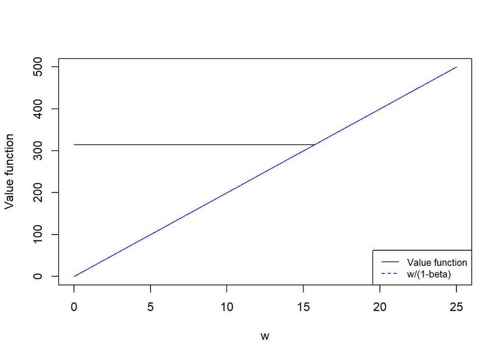

```r
# Value function plot
plot(w_grid, V_obj, t="l",
     ylab="Value function", xlab="w", ylim=c(0, V_obj[length(w_grid)]))
lines(w_grid,w_grid/(1-BETA), col = "blue")
legend("bottomright", legend=c("Value function", "w/(1-beta)"),
       col=c("black", "blue"), lty=1:2, cex=0.8)
```

The value function is constant until the reservation wage has been reached. The reservation wage is the lowest wage the worker is willing to accept an offer and work. Below the reservation wage the expected value of future earnings is too low and the worker remains unemployed and waits for a better offer. For all wages above the reservation wage the value function increases in $w$ since then the lifetime value is given by $\frac{w}{1-\beta}$. The kink in the function denotes the reservation wage.

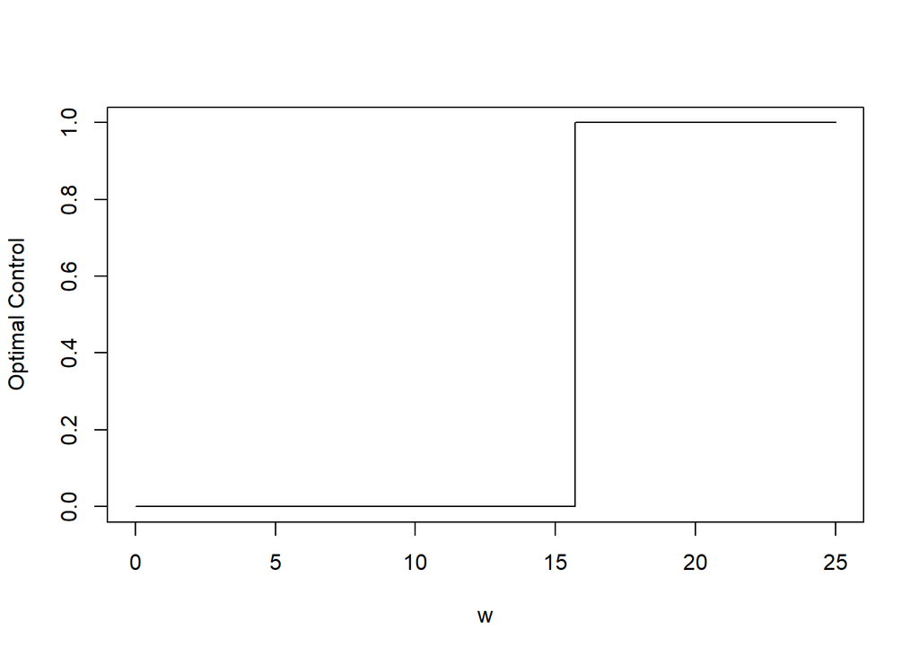

```r
## Optimal control/Decision rule
plot(w_grid, optimal_decision[, 1]=="true", t="l",
     ylab="Optimal Control", xlab="w")
```

```r
reservation_wage <- w_grid[which('true' == optimal_decision)[1]]
print(reservation_wage)
```

```
## [1] 15.71
```

The policy can take on the values TRUE (1) or FALSE (0) i.e., accept an offer or decline an offer respectively. The plot shows that if an offer is below the reservation wage the worker should always decline the offer. An offer should only be accepted if the wage offer is higher than the reservation wage.

3. Simulate $1.000$ episodes of length $T=100$ and store the acceptance time period for each episode, i.e. the period when the worker accepts the wage offer and is employed from then onwards till infinity. Also, calculate the average discounted return that the agent receives over the $1.000$ episodes. Then, …
   1. plot a histogram of acceptance time periods.
   2. compare the average discounted return to the value function: Plug $1.000$ (maximum) wage offers into the value function that you calculated in Exercise 2a and take the mean of the $1.000$ resulting values.

> *Remark:* Although we cannot simulate an infinite horizon, the episode length is chosen so that the probability of not accepting a wage offer during this time is negligibly small. Take account of the infinite horizon, when calculating the average discounted return (cue: infinite geometric series).

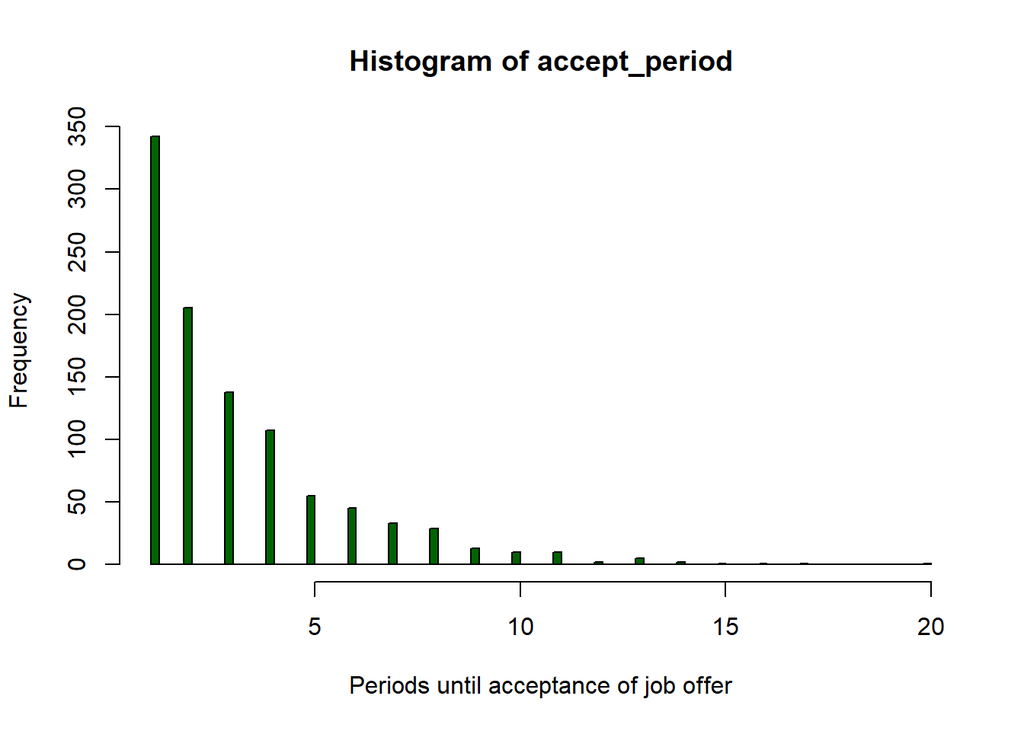

```r
# Calculate for 1000 episodes at what period an offer gets accepted and
# the discounted future value.
set.seed(1234)
for(i in 1:episodes){
  sim <- apply(matrix(rtnorm(200, mean=MU, sd=sqrt(VAR), a=0, b=Inf),
                      100, 2), 1, FUN=max)
  accept_period[i] <- Position(function(x) x > reservation_wage, sim)

  length_unemp <- accept_period[i]-1
  unemp_comp <- rep(comp, (length_unemp))

  discount_factors <- BETA^(0:(length_unemp-1))

  unemp_discounted <- sum(unemp_comp * discount_factors)

  wage_discounted <- sim[accept_period[i]]/(1-BETA) * BETA^(accept_period[i]-1)

  disc_return[i] <- unemp_discounted + wage_discounted

}
# Plot histogram of the period an offer is accepted
hist(accept_period, breaks = 70, xlab = "Periods until acceptance of job offer",
     col = "darkgreen")
```

```r
# Average discounted return that the agent receives over 1000 episodes
avg_disc_return <- mean(disc_return)
print(avg_disc_return)
```

```
## [1] 324.4311
```

```r
# Value function estimate
V <- approxfun(w_grid, V_obj, rule = 2)
# Plugging in 1000 wage offers into the value function and take the mean
mean(V(apply(matrix(rtnorm(2000, mean=MU, sd=sqrt(VAR), a=0, b=Inf),
                    1000, 2), 1, FUN=max)))
```

```
## [1] 326.2501
```

The average discounted returns and the Value function estimate yield quite similar values.

4. Now assume that the unemployed worker can only draw **one** wage offer from the truncated normal distribution from above in each period. Determine the value function and policy function again, graphically compare the results to the previous results and explain the difference.

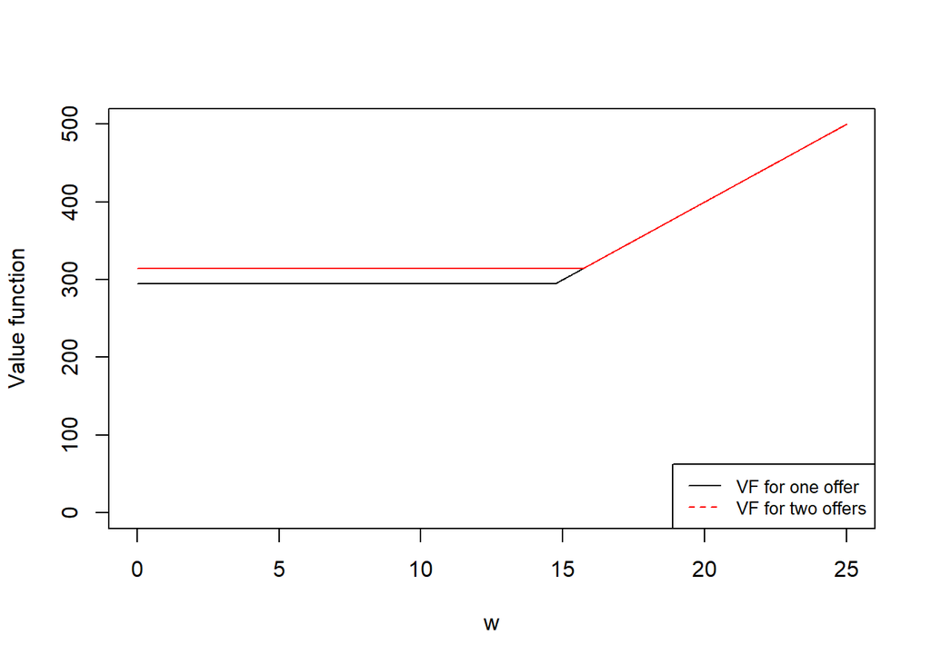

```r
# Value function for only one job offer per period
get_value_2 <- function(accept,
                      V_obj,
                      wage_offer,
                      compensation,
                      beta,
                      w_grid,
                      var,
                      mu){
  if(accept){
    return(wage_offer/(1-beta))
  }
  else{
    set.seed(1234)
    sim_tnrom <- rtnorm(10000, mean=MU, sd=sqrt(VAR), a=0, b=Inf)
    V <- approxfun(w_grid, V_obj, rule = 2)
    return(compensation + beta* mean(V(sim_tnrom)))
  }
}


# Value function iteration for only one job offer per period
repeat{
  for(i in 1:length(w_grid)){
    values2$true <- get_value_2(TRUE,
                             V_obj = V_obj2,
                             wage_offer = w_grid[i],
                             compensation = comp,
                             beta = BETA,
                             w_grid = w_grid,
                             var = VAR,
                             mu = MU)
    values2$false <- get_value_2(FALSE,
                              V_obj = V_obj2,
                              wage_offer = w_grid[i],
                              compensation = comp,
                              beta = BETA,
                              w_grid = w_grid,
                              var = VAR,
                              mu = MU)
    V_new2[i] <- max(unlist(values2), na.rm=TRUE)
    optimal_decision2[i] <- names(which.max(values2))
  }
  if (max(abs(V_new2 - V_obj2)) < 0.001) {
    break
  }

  V_obj2 <- V_new2
}

# Plot value function for only one job offer each period
plot(w_grid, V_obj2, t="l",
     ylab="Value function", xlab="w", ylim=c(0, V_obj2[length(w_grid)]))
lines(w_grid,V_obj, col = "red")
legend("bottomright", legend=c("VF for one offer", "VF for two offers"),
       col=c("black", "red"), lty=1:2, cex=0.8)
```

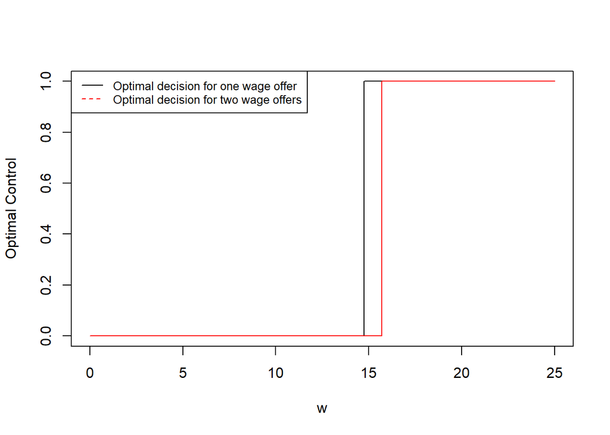

```r
## Optimal control/Decision rule for only one job offer each period
plot(w_grid, optimal_decision2[, 1]=="true", t="l",
     ylab="Optimal Control", xlab="w")
lines(w_grid, optimal_decision[, 1]=="true", t = "l", col = "red")
legend("topleft", legend=c("Optimal decision for one wage offer", "Optimal decision for two wage offers"),
       col=c("black", "red"), lty=1:2, cex=0.8)
```

```r
reservation_wage2 <- w_grid[which('true' == optimal_decision2)[1]]
print(reservation_wage2)
```

```
## [1] 14.75
```

If the worker only faces one job offer from the truncated normal distribution per period the reservation wage is lower. On average the job offers are higher if two offers are made in one period. It is more likely that the two options yield a better offer than just one option. Hence, the expected future returns increase and also the reservation wage. Since higher expected wages result in higher values (in the value function) workers will only accept jobs at higher wages if there are two offers.This becomes visible in the optimal control plot, since the reservation wage where workers accept an offer shifts to the right.

### Reinforcement Learning

**Exercise 3**

1. Solve the original wage acceptance problem (**two wage offers**) with Q-Learning. In order to explore the whole state action space generate the episodes with exploring starts (choose the starting state randomly from a sensible range and distribution). Additionally, use an $\varepsilon$-greedy policy with $\varepsilon=0.1$. Set the step-size parameter $\alpha = 0.1$ and run the algorithm for $1.000.000$ episodes. All other parameters are already given above.

> *Remark:* As Q-learning is a tabular method and only works for discrete state-action spaces you will need to discretize the draws from the truncated normal distribution. Be aware that rounding methods are often fraught with problems due to computer arithmetic ([see *Warning* in the R-Documentation](https://rdrr.io/r/base/Round.html)). At the cost of some inaccuracy you could use the $\textit{trunc}$ command to tackle unexpected results that result from $\textit{round}$. To make the grid granularity of the two exercises comparable keep the first decimal place of each draw. Example: Assume you draw 12.3456 from the truncated normal distribution and your Q-table has 301 rows for states $\{0.0, 0.1, 0.2, ..., 30.0\}$. Thus, you should update one of the state action values in the 124th row of the Q-table. To index the Q-table correctly do the following: First calculate the index via `index <- trunc(12.3456 * 10)+1`, then index the Q-table: `q_table[index, action]`.

```r
# Hyperparameters

TT <- 1000000
alpha <- 0.1  # Step-size parameter
epsilon <- 0.1 # Deviation probability

actions <- c(1, 2) # Either accept (1) or decline (2) the job offer

# Grids and arrays (already for task 3.c too)

w_grid <- seq(0,30, by = 0.1) # State space
action <- rep(NA, TT) # Action space
q_table <- matrix(0, nrow = length(w_grid), ncol = length(actions))
q_table_2 <- matrix(0, nrow = length(w_grid), ncol = length(actions))
policy <- matrix(1, nrow = length(w_grid), ncol = length(actions))
policy_2 <- matrix(1, nrow = length(w_grid), ncol = length(actions))
wage <- matrix(NA, ncol = 1, nrow = TT)
VF <- matrix(0, length(w_grid)) # Value function
PF <- matrix(0, length(w_grid)) # Policy function
VF_2 <- matrix(0, length(w_grid)) # Value function for task 3.c
PF_2 <- matrix(0, length(w_grid)) # Policy function for task 3.c
deltas <- rep(0,TT) # Temporal difference term
deltas_2 <- rep(0,TT)


# Generate TT wage offers and index them such that they fit in the discrete grid
wage_offer <- apply(matrix(rtnorm(2*TT, mean=MU, sd=sqrt(VAR), a=0, b=Inf),
                           TT, 2), 1, FUN=max)
index <- trunc(wage_offer * 10)+1

# Q-learning algorithm:
for(i in 1:(TT)){
  action <- sample(actions, 1, prob = policy[index[i],])

  # Compute TD error
  if (action == 2){
    deltas[i] <- comp+ BETA * max(q_table[index[i+1],]) - q_table[index[i], 2]
  } else{
    deltas[i] <- wage_offer[i] + BETA * q_table[index[i],1 ] - q_table[index[i], 1]
  }

  # Update Q (Action-value function)
  q_table[index[i], action] <- q_table[index[i], action] + alpha * deltas[i]


  # Find out which actions are greedy or non-greedy
  greedy_action <- which.max(q_table[index[i],])
  non_greedy_action <- actions[-greedy_action]

  # Set new policy
  policy[index[i], non_greedy_action] <- epsilon
  policy[index[i], greedy_action] <- 1- epsilon

  VF[index[i]] <- weighted.mean(q_table[index[i],], w = policy[index[i],])
  PF[index[i]] <- which.max(policy[index[i],])

}
```

2. Plot the value and policy function and compare them with the results from exercise 2.

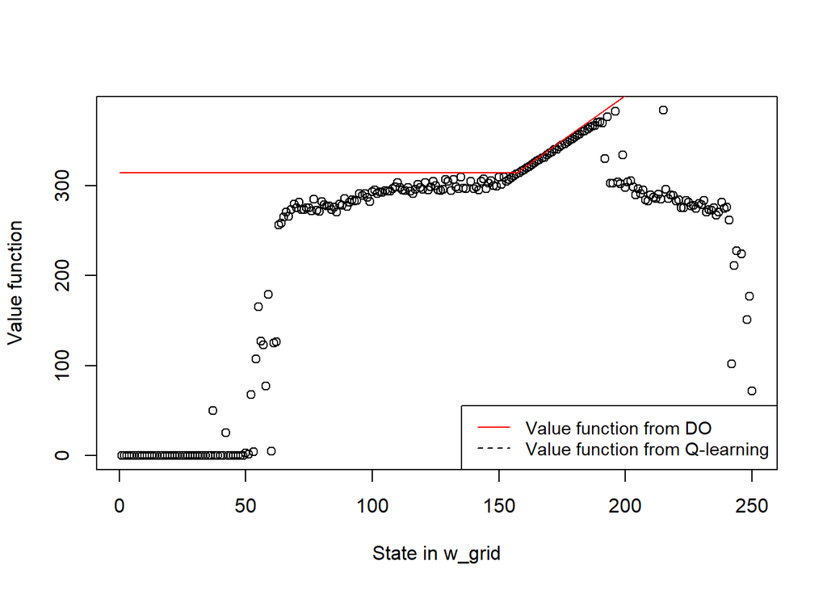

```r
# Plot Value function and Policy function
plot(VF[1:250], ylab = "Value function", xlab = "State in w_grid")
lines(seq(0,25, by = 0.01)*10,V_obj, col = "red")
legend("bottomright", legend=c("Value function from DO", "Value function from Q-learning"),
       col=c("red", "black"), lty=1:2, cex=0.9)
```

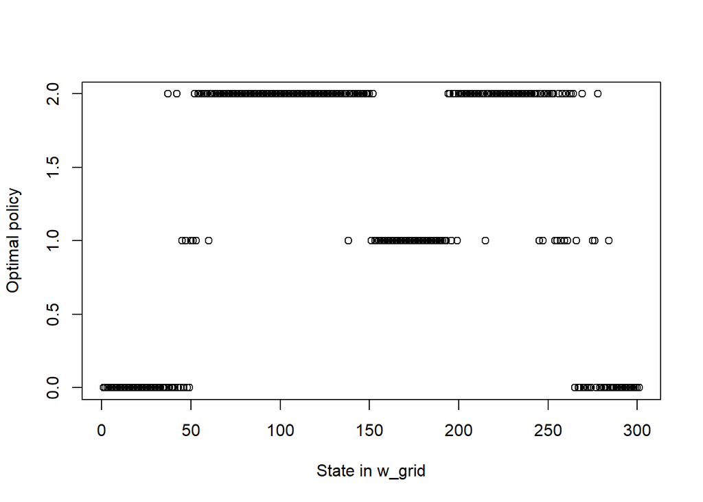

```r
plot(PF, ylab = "Optimal policy", xlab = "State in w_grid")
```

3. The resulting value function above is still quite far off from the value function determined by dynamic programming. To improve the Q-learning algorithm implement a learning schedule for the step-size parameter $\alpha$ and the exploration rate $\varepsilon$: Every $200.000$ episodes decrease both parameters by a factor of $0.5$. Set the starting values to $\alpha=0.3$ and $\varepsilon=0.5$. Again, plot both value and policy function. Argue why such a learning schedule improves the accuracy of the algorithm.

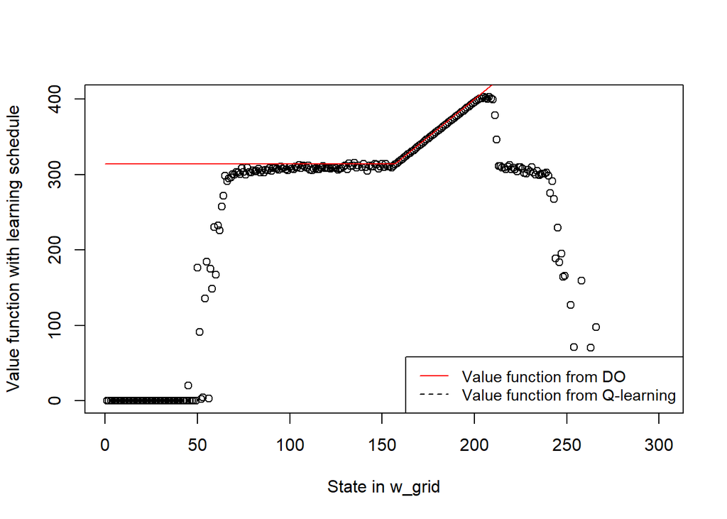

```r
# Change in Hyperparameters

alpha <- 0.3  # Step-size parameter
epsilon <- 0.5 # Deviation probability

# Again Q-learning algorithm but this time with learning schedule
for(i in 1:(TT)){
  action <- sample(actions, 1, prob = policy_2[index[i],])

  # Compute TD error
  if (action == 2){
    deltas_2[i] <- comp+ BETA * max(q_table_2[index[i+1],]) - q_table_2[index[i], 2]
  } else{
    deltas_2[i] <- wage_offer[i] + BETA * q_table_2[index[i],1 ] - q_table_2[index[i], 1]
  }

  # Update Q (Action-value function)
  q_table_2[index[i], action] <- q_table_2[index[i], action] + alpha * deltas_2[i]


  # Find out which actions are greedy or non-greedy
  greedy_action <- which.max(q_table_2[index[i],])
  non_greedy_action <- actions[-greedy_action]

  # Set new policy
  policy_2[index[i], non_greedy_action] <- epsilon
  policy_2[index[i], greedy_action] <- 1- epsilon

  VF_2[index[i]] <- weighted.mean(q_table_2[index[i],], w = policy_2[index[i],])
  PF_2[index[i]] <- which.max(policy_2[index[i],])

  if(i%%200000 == 0){
    alpha <- alpha * 0.5
    epsilon <- epsilon * 0.5
  }

}

plot(VF_2, ylab = "Value function with learning schedule", xlab = "State in w_grid")
lines(seq(0,25, by = 0.01)*10,V_obj, col = "red")
legend("bottomright", legend=c("Value function from DO", "Value function from Q-learning"),
       col=c("red", "black"), lty=1:2, cex=0.9)
```

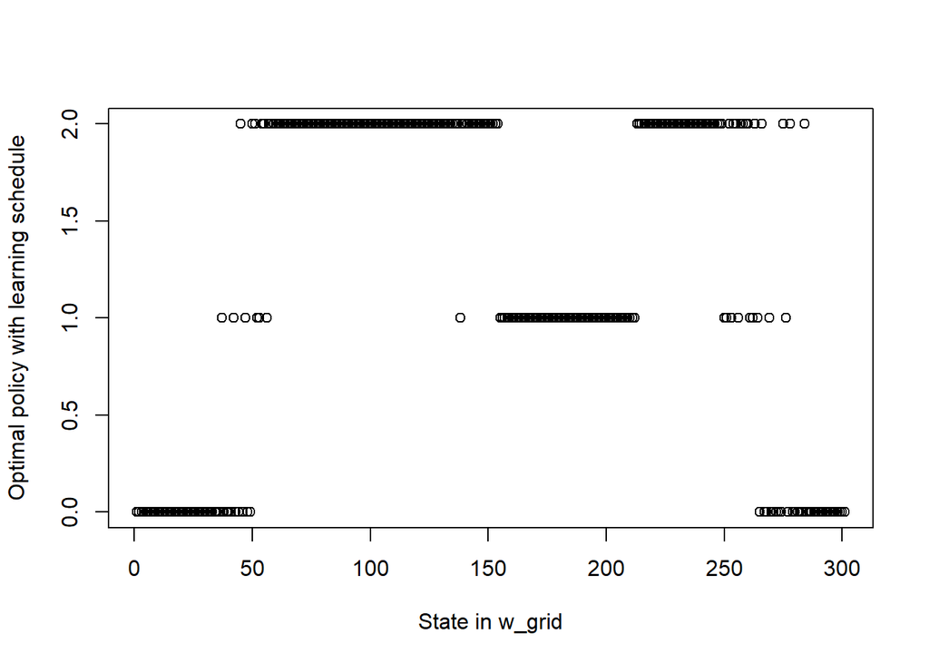

```r
plot(PF_2, ylab = "Optimal policy with learning schedule", xlab = "State in w_grid")
```

Choosing a large $\epsilon$ allows to explore more state action pairs more often. However, a large $\epsilon$ is far from being optimal if used all the time. An $\epsilon$ too small, however, does not ensure that we explore enough and greedy actions might not always be the optimal thing to do. So starting with a large $\epsilon$ ensures that we are exploring the state action space and the in i decreasing epsilon ensures that our policy becomes more optimal. A high $\alpha$ at the beginning ensures that the worker learns relatively fast and overwrites old information relatively quickly. If $\alpha$ decreases in i, the agent learns less quickly, however, she considers old information in more depth.

4. Again (as in exercise 2c), simulate $1.000$ episodes of length $T=100$ and calculate the average discounted return that the agent receives over the $1.000$ episodes, if she…

follows the policy derived by exercise 3a.  
follows the policy derived by exercise 3c.

```r
episodes <- 1000
tt <- 100
Q_return_2 <- rep(0, episodes)
Q_return_1 <- rep(0, episodes)

# Average discounted return for policy derived by 3.a
for(i in 1:episodes){
  counter <- 0
  repeat{
    sim_q <- apply(matrix(rtnorm(2, mean=MU, sd=sqrt(VAR), a=0, b=Inf),
                          1, 2), 1, FUN=max)
    index <- trunc(sim_q * 10)+1
    counter <- counter + 1

    if(PF[index] == 2|counter == tt){
      length_unemp <- counter - 1
      unemp_comp <- rep(comp, (length_unemp))
      discount_factors <- BETA^(0:(length_unemp-1))
      unemp_discounted <- sum(unemp_comp * discount_factors)
      wage_discounted <- sim_q/(1-BETA) * BETA^(counter-1)
      Q_return_1[i] <- unemp_discounted + wage_discounted;
      break
    }
  }
}

mean(Q_return_1)
```

```
## [1] 259.7097
```

```r
# Average discounted return for policy derived by 3.c
for(i in 1:episodes){
  counter <- 0
  repeat{
    sim_q <- apply(matrix(rtnorm(2, mean=MU, sd=sqrt(VAR), a=0, b=Inf),
                          1, 2), 1, FUN=max)
    index <- trunc(sim_q * 10)+1
    counter <- counter + 1

    if(PF_2[index] == 2|counter == tt){
      length_unemp <- counter - 1
      unemp_comp <- rep(comp, (length_unemp))
      discount_factors <- BETA^(0:(length_unemp-1))
      unemp_discounted <- sum(unemp_comp * discount_factors)
      wage_discounted <- sim_q/(1-BETA) * BETA^(counter-1)
      Q_return_2[i] <- unemp_discounted + wage_discounted;
      break
    }
  }
}

mean(Q_return_2)
```

```
## [1] 257.4492
```